# Indel Signature InsDel_J

# InsDel_J

(corresponds to 83-type signature ID_J)

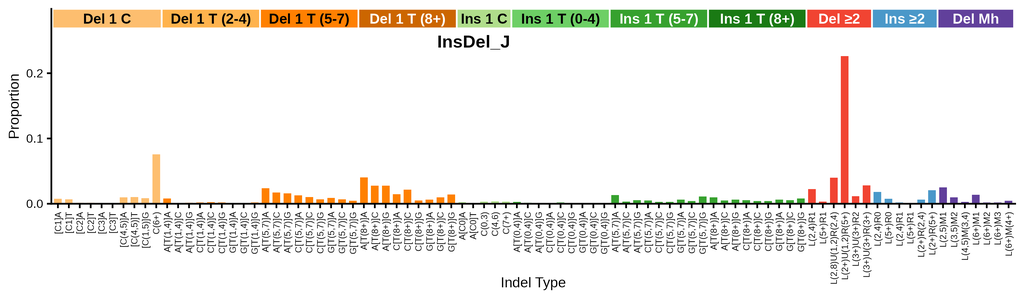

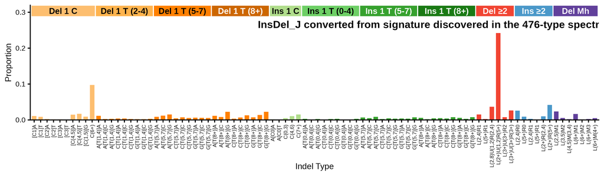

89-type spectrum of the linking tumor DRUP01010037T | cosine similarity to InsDel_J: 0.5628

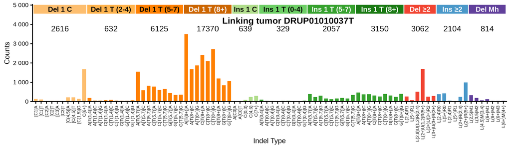

**Click to view decomposition of the linking tumor spectrum**

Partial mutation signature of DRUP01010037T due to InsDel_J

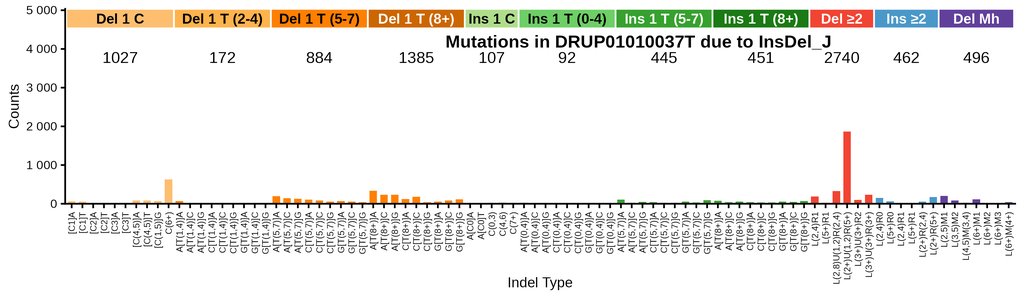

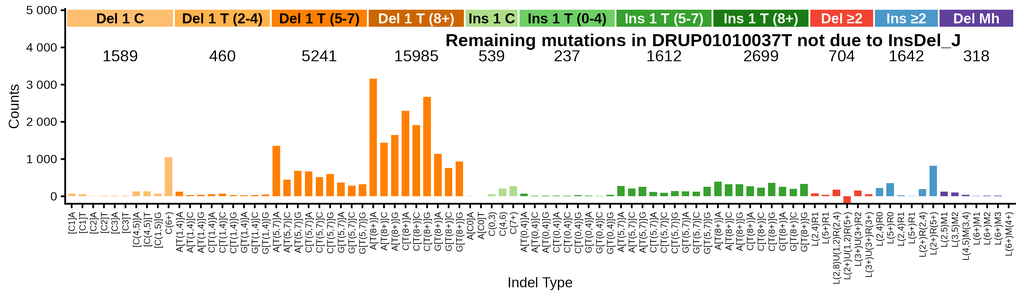

Max neg fraction (maximum allowed negative residual count as fraction of total): 0.01  
N subtract (mutation count assigned to signature): 8260.8  
N residual (mutation count in residual “partial spectrum”): 30637.2  
Total negative (sum of negative residual mutation counts): 194.5  
N negative channels (number of channels with negative residual): 3  
P(≥ total negative) (Monte Carlo estimated probability that negative-binomial-sampled spectra from the signature contributing N subtract mutations would produce a total negative count >= the observed Total negative; higher number means not surprising): 0.429

**Per-channel residual breakdown**

| Channel | Spectrum | Sig_Count | Residual | Sig_Prop |
| --- | --- | --- | --- | --- |
| [Del(C):R1]A | 137 | 64.5 | 72.5 | 0.00780 |
| [Del(C):R1]T | 110 | 55.9 | 54.1 | 0.00677 |
| [Del(C):R2]A | 26 | 14.4 | 11.6 | 0.00175 |
| [Del(C):R2]T | 31 | 13.3 | 17.7 | 0.00161 |
| [Del(C):R3]A | 31 | 9.6 | 21.4 | 0.00116 |
| [Del(C):R3]T | 26 | 6.9 | 19.1 | 0.00083 |
| [Del(C):R(4,5)]A | 217 | 81.2 | 135.8 | 0.00983 |
| [Del(C):R(4,5)]T | 218 | 83.2 | 134.8 | 0.01008 |
| [Del(C):R(1,5)]G | 143 | 70.7 | 72.3 | 0.00856 |
| Del(C):R(6,9) | 1677 | 626.9 | 1050.1 | 0.07589 |
| A[Del(T):R(1,4)]A | 189 | 67.2 | 121.8 | 0.00814 |
| A[Del(T):R(1,4)]C | 46 | 9.8 | 36.2 | 0.00119 |
| A[Del(T):R(1,4)]G | 49 | 12.1 | 36.9 | 0.00147 |
| C[Del(T):R(1,4)]A | 71 | 15.2 | 55.8 | 0.00184 |
| C[Del(T):R(1,4)]C | 87 | 18.9 | 68.1 | 0.00228 |
| C[Del(T):R(1,4)]G | 51 | 15.6 | 35.4 | 0.00189 |
| G[Del(T):R(1,4)]A | 39 | 10.6 | 28.4 | 0.00128 |
| G[Del(T):R(1,4)]C | 38 | 7.2 | 30.8 | 0.00087 |
| G[Del(T):R(1,4)]G | 62 | 15.1 | 46.9 | 0.00183 |
| A[Del(T):R(5,7)]A | 1551 | 196.0 | 1355 | 0.02373 |
| A[Del(T):R(5,7)]C | 585 | 141.2 | 443.8 | 0.01710 |
| A[Del(T):R(5,7)]G | 819 | 132.3 | 686.7 | 0.01601 |
| C[Del(T):R(5,7)]A | 777 | 105.5 | 671.5 | 0.01277 |
| C[Del(T):R(5,7)]C | 598 | 86.3 | 511.7 | 0.01045 |
| C[Del(T):R(5,7)]G | 653 | 56.2 | 596.8 | 0.00680 |
| G[Del(T):R(5,7)]A | 440 | 72.5 | 367.5 | 0.00877 |
| G[Del(T):R(5,7)]C | 342 | 56.2 | 285.8 | 0.00680 |
| G[Del(T):R(5,7)]G | 360 | 37.6 | 322.4 | 0.00455 |
| A[Del(T):R(8,)]A | 3497 | 332.5 | 3164.5 | 0.04025 |
| A[Del(T):R(8,)]C | 1672 | 230.2 | 1441.8 | 0.02787 |

[output cut: 59 more lines]

## 476-type representations corresponding to InsDel_J

Extracted 476-type signature corresponding to InsDel_J

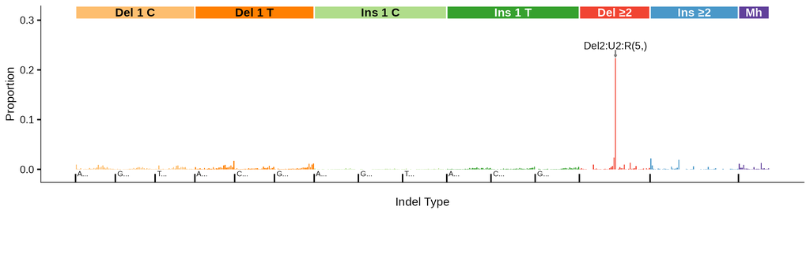

476-type spectrum of the linking tumor DRUP01010037T; cosine similarity to the extracted 476-type signature is 0.416

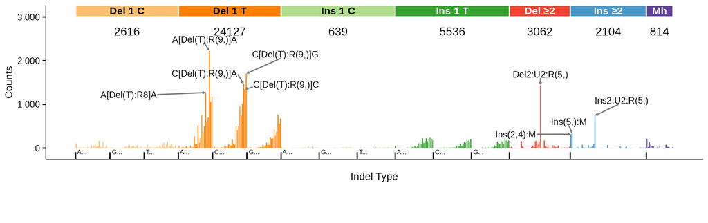

## 83-type signature corresponding to InsDel_J (ID_J)

**Note**

ID_J usually co-occurs with C_ID7 in MSI tumors

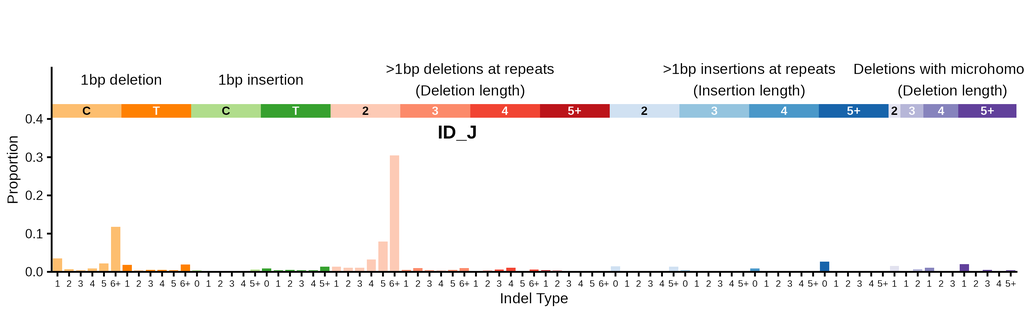

83-type signature converted from signature discovered in the 476-type spectra (using bipartite matching optimization) | cosine similarity to ID_J: 0.8175

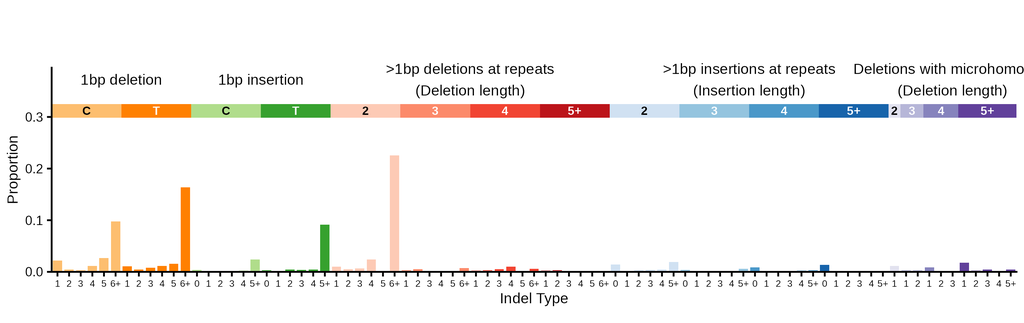

**Click here to see with insertions and deletions of T in long poly-T suppressed**

[figure not shown]

**Click to see flow diagrams: 476-type to 83-type collapse**

These Sankey diagrams show how the 476-type mutation categories are redistributed to 83-type categories using bipartite matching. We only show the diagrams for insertions or deletions of > 1 base because it is for these indels that 476-type categories map to > 1 83-type category.

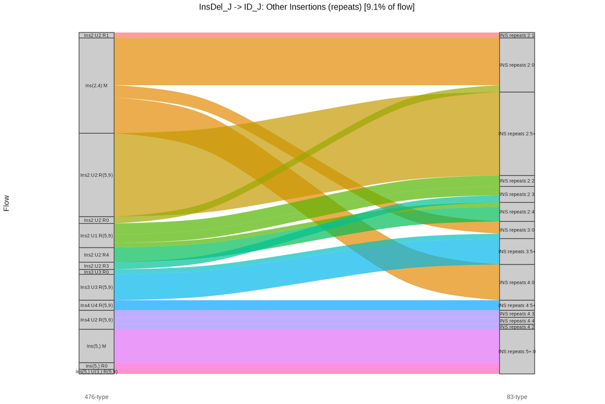

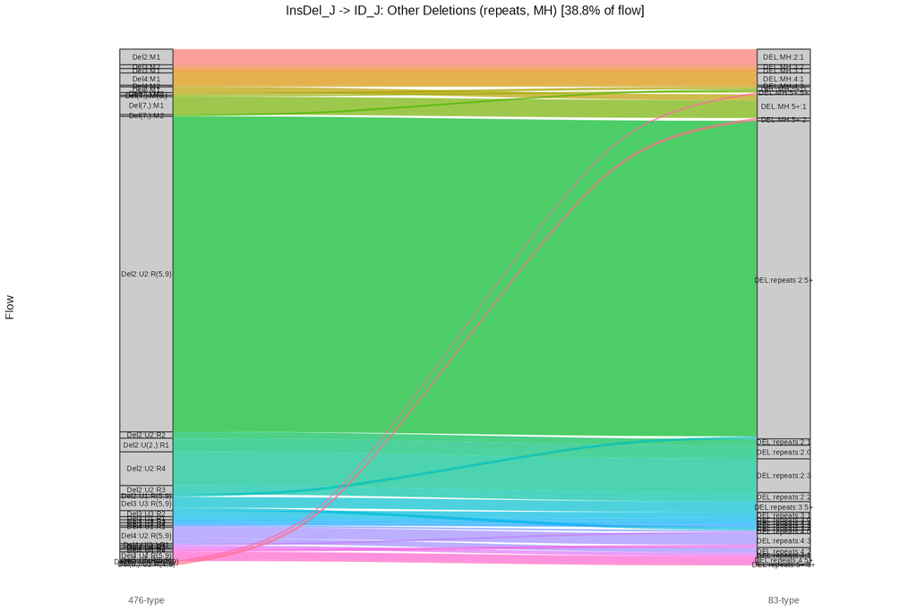

**Caution**

For the linking tumor plot, mutation counts for insertions and deletions of T in long-poly-T contexts were set to 0. They were also set to 0 when calculating cosine similarity with the signature. The signature was not altered when computing the cosine similarity.

83-type spectrum of the linking tumor DRUP01010037T | cosine similarity to ID_J: 0.7288

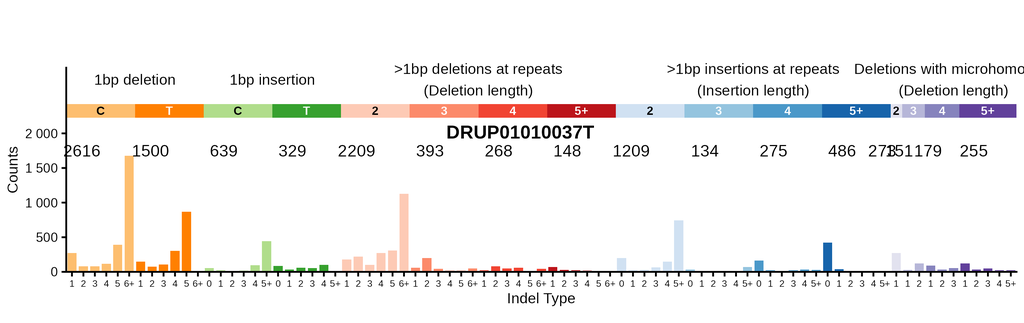

83-type spectrum of best 83-type matching tumor SP112959 | cosine similarity to ID_J: 0.7348

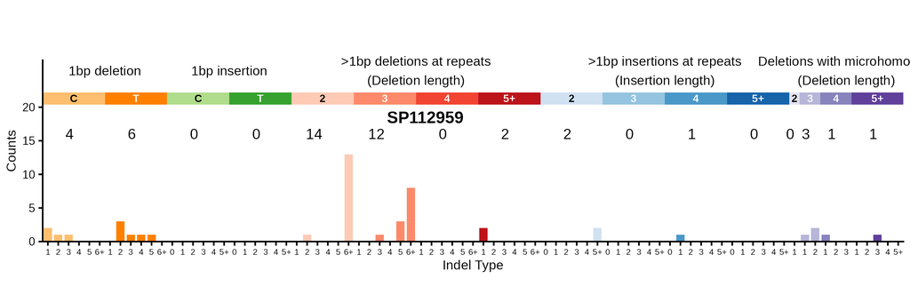